# Patrones de puntos

Kenneth Roy Cabrera Torres

20 de abril de 2016

## Lectura de la base de datos.

Distribución de la especie Hybanthus prunifolius (flor de lluvia) con un DAP mayor de 5 cm.

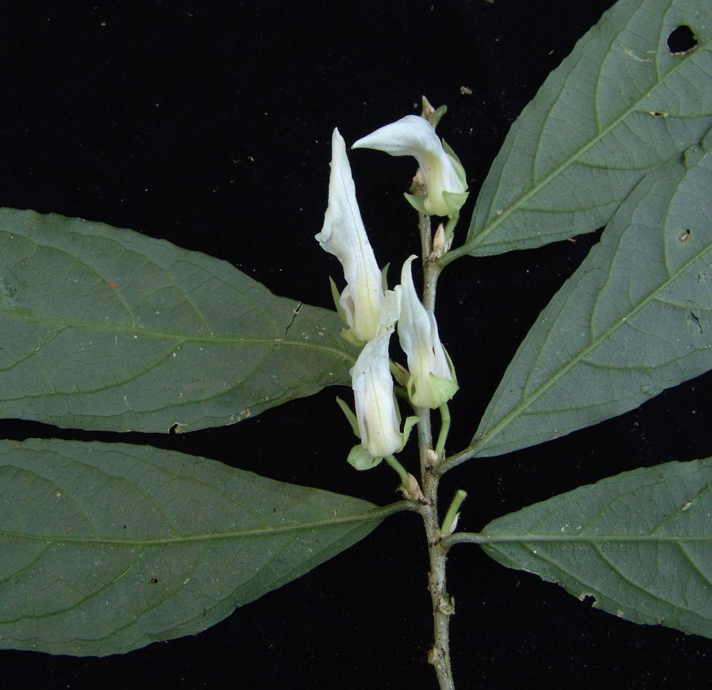

De acuerdo a la descripción hecha en [esta página](http://www.tropicos.org/name/33800563?projectid=7), se caracteríza por:

Arbustos o árboles, hasta 7 m de alto; ramas jóvenes pilosas, estriadas, gris claras. Hojas alternas, frecuentemente agrupadas en brotes cortos, elípticas, 4.5–15 cm de largo, atenuadas a acuminadas en el ápice, atenuadas en la base, irregularmente serradas o serruladas, lisas, adaxialmente seríceas a lo largo del nervio principal, abaxialmente seríceas cuando jóvenes, tricomas persistentes en el base y a lo largo del nervio principal; pecíolos cortos, estípulas 3–5 mm de largo, con una quilla ósea y con márgenes cartáceos, seríceas a lo largo de la quilla, persistentes. Flores 1–2 en brotes cortos, blancas, pedicelos delgados, 10–20 mm de largo; sépalos lanceolados, 7–11 mm de largo, seríceos; pétalo más inferior 23–45 mm de largo. Cápsula 18–20 mm de largo; semillas 4–5 mm de diámetro.

```r
hp1<-read.csv2("Hp.csv",enc="latin1")
```

## Uso del paquete **spatstat**

```r
require(spatstat)
```

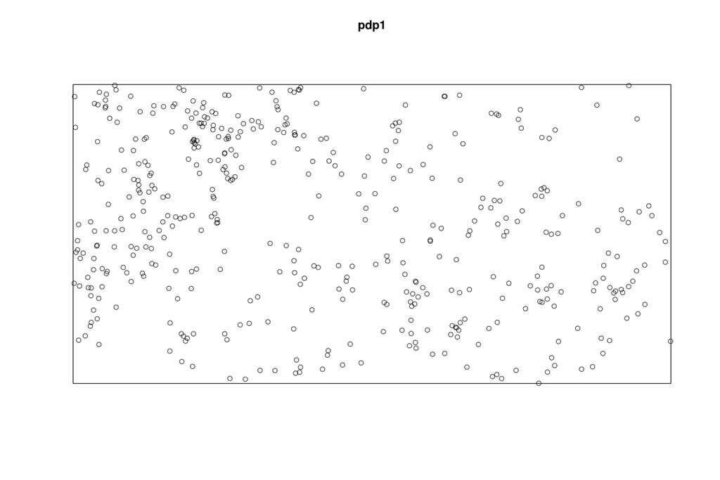

```r
## Convertir a un objeto de patrones de puntos
pdp1<-ppp(hp1$x,hp1$y,c(0,1000),c(0,500),unitname=c("metro","metros"))

## Gráfica del objeto de patrones de puntos.
plot(pdp1)
```

```r
## Resumen del objeto de patrones de puntos.
summary(pdp1)
```

```
## Planar point pattern:  450 points
## Average intensity 9e-04 points per square metro
##
## Coordinates are given to 1 decimal place
## i.e. rounded to the nearest multiple of 0.1 metros
##
## Window: rectangle = [0, 1000] x [0, 500] metros
## Window area = 5e+05 square metros
## Unit of length: 1 metro
```

## Cálculo de la densidad mediante cuadrantes.

Prueba de hipóteis para saber si los puntos se distribuyen al azar o tienen algún patrón.

```r
CC1<-quadratcount(pdp1,nx=10,ny=5)
CC1
```

```
##            x
## y           [0,100) [100,200) [200,300) [300,400) [400,500) [500,600)
##   [400,500]      16        16        32        23         4         6
##   [300,400)       8        18        21         3         9         8
##   [200,300)      18        19         7         5         2         7
##   [100,200)      19         9         4         7         9        15
##   [0,100)         4         7         6         7         6         7
##            x
## y           [600,700) [700,800) [800,900) [900,1000]
##   [400,500]         6         7         3          2
##   [300,400)         3         8         1          1
##   [200,300)         9         8         4         10
##   [100,200)         5        14         8         12
##   [0,100)          11         6         9          1
```

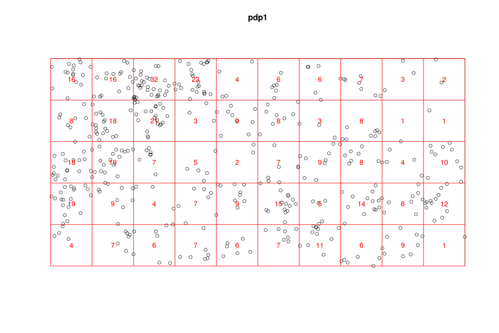

```r
plot(pdp1,pch=1)
plot(CC1,add=TRUE,col="red")
```

```r
quadrat.test(pdp1,nx=10,ny=5)
```

```
##
##  Chi-squared test of CSR using quadrat counts
##  Pearson X2 statistic
##
## data:  pdp1
## X2 = 223.56, df = 49, p-value < 2.2e-16
## alternative hypothesis: two.sided
##
## Quadrats: 10 by 5 grid of tiles
```

```r
quadrat.test(pdp1,alternative="regular",nx=10,ny=5)
```

```
##
##  Chi-squared test of CSR using quadrat counts
##  Pearson X2 statistic
##
## data:  pdp1
## X2 = 223.56, df = 49, p-value = 1
## alternative hypothesis: regular
##
## Quadrats: 10 by 5 grid of tiles
```

```r
quadrat.test(pdp1,alternative="clustered",nx=10,ny=5)
```

```
##
##  Chi-squared test of CSR using quadrat counts
##  Pearson X2 statistic
##
## data:  pdp1
## X2 = 223.56, df = 49, p-value < 2.2e-16
## alternative hypothesis: clustered
##
## Quadrats: 10 by 5 grid of tiles
```

## Gráfica de la estimación usando el K de Ripley.

$$K(r) = \lambda^{-1} E[\textrm{número extra de eventos en una distancia r de un evento aleatorio}]$$

Dónde $\lambda$ es la densidad (número de unidades por área) de los eventos.

Para un proceso poisson homogéneo que también se conoce como un CSR (Complete Spatial Randomness) la función $K(r)$ se define como:

$$K(r) = \pi r^2$$

```r
KR1 <- Kest(pdp1)
KR1
```

```
## Function value object (class 'fv')
## for the function r -> K(r)
## ..............................................................
##        Math.label       Description
## r      r                distance argument r
## theo   K[pois](r)       theoretical Poisson K(r)
## border hat(K)[bord](r)  border-corrected estimate of K(r)
## trans  hat(K)[trans](r) translation-corrected estimate of K(r)
## iso    hat(K)[iso](r)   isotropic-corrected estimate of K(r)
## ..............................................................
## Default plot formula:  .~r
## where "." stands for 'iso', 'trans', 'border', 'theo'
## Recommended range of argument r: [0, 125]
## Available range of argument r: [0, 125]
## Unit of length: 1 metro
```

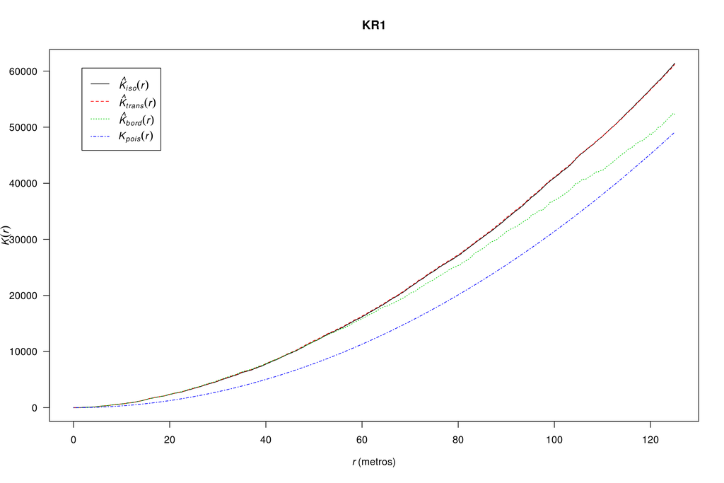

```r
plot(KR1, las = 1)
```

## Estimación de estructura espacial de patrones de puntos.

[output not shown]

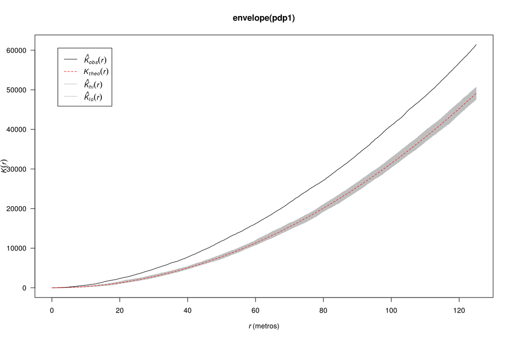

```r
plot(envelope(pdp1), las = 1)
```

## Estimación de la densidad de patrones de puntos.

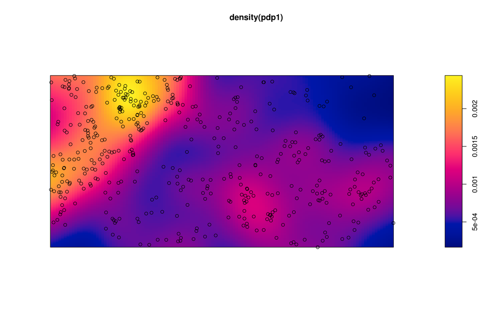

```r
plot(density(pdp1))
points(pdp1)
```

## Modelación de patrones de puntos

```r
m1<-ppm(pdp1,~x+y+x:y,Poisson())
m1
```

```
## Nonstationary Poisson process
##
## Log intensity:  ~x + y + x:y
##
## Fitted trend coefficients:
##   (Intercept)             x             y           x:y
## -7.445177e+00  4.992622e-04  3.481007e-03 -6.187302e-06
##
##                  Estimate         S.E.       CI95.lo       CI95.hi Ztest
## (Intercept) -7.445177e+00 1.914514e-01 -7.820414e+00 -7.069939e+00   ***
## x            4.992622e-04 3.432829e-04 -1.735599e-04  1.172084e-03
## y            3.481007e-03 5.874170e-04  2.329691e-03  4.632324e-03   ***
## x:y         -6.187302e-06 1.161869e-06 -8.464524e-06 -3.910081e-06   ***
##                   Zval
## (Intercept) -38.888083
## x             1.454375
## y             5.925956
## x:y          -5.325301
```

```r
summary(m1)
```

```
## Point process model
## Fitting method: maximum likelihood (Berman-Turner approximation)
## Model was fitted using glm()
## Algorithm converged
## Call:
## ppm.ppp(Q = pdp1, trend = ~x + y + x:y, interaction = Poisson())
## Edge correction: "border"
##  [border correction distance r = 0 ]
## ---------------------------------------------------------------------------
## Quadrature scheme = data + dummy + weights
##
## Data pattern:
## Planar point pattern:  450 points
## Average intensity 9e-04 points per square metro
## Window: rectangle = [0, 1000] x [0, 500] metros
## Window area = 5e+05 square metros
## Unit of length: 1 metro
##
## Dummy quadrature points:
##      (50 x 50 grid, plus 4 corner points)
## Planar point pattern:  2504 points
## Average intensity 0.00501 points per square metro
## Window: rectangle = [0, 1000] x [0, 500] metros
## Window area = 5e+05 square metros
## Unit of length: 1 metro
## Quadrature weights:
##      (counting weights based on 50 x 50 array of rectangular tiles)
## All weights:
##  range: [33.3, 200]  total: 5e+05
## Weights on data points:
##  range: [33.3, 100]  total: 40600
## Weights on dummy points:
##  range: [33.3, 200]  total: 459000
## ---------------------------------------------------------------------------
## FITTED MODEL:
##
## Nonstationary Poisson process
##
## ---- Intensity: ----
##
```

[output cut: 11 more lines]

```
##                   Zval
## (Intercept) -38.888083
## x             1.454375
## y             5.925956
## x:y          -5.325301
##
## ----------- gory details -----
##
## Fitted regular parameters (theta):
##   (Intercept)             x             y           x:y
## -7.445177e+00  4.992622e-04  3.481007e-03 -6.187302e-06
##
## Fitted exp(theta):
##  (Intercept)            x            y          x:y
## 0.0005842529 1.0004993868 1.0034870731 0.9999938127
```

[output not shown]

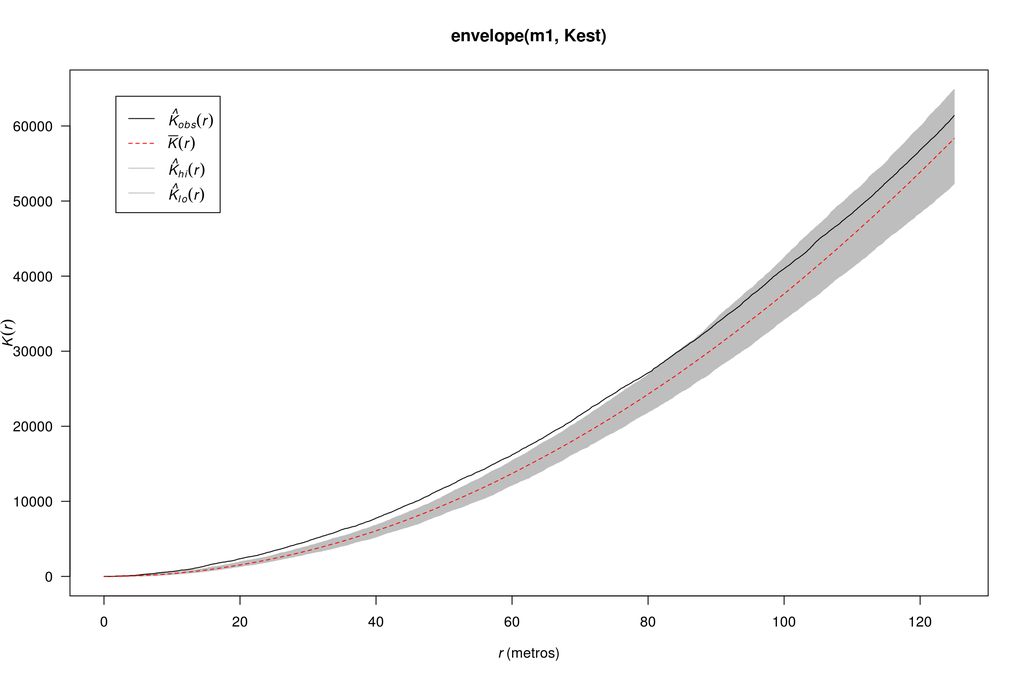

```r
plot(envelope(m1,Kest), las = 1)
```